# Aside

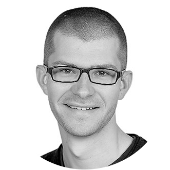

## Contact Info

- mike.smith@embl.de
- github.com/grimbough
- 0000-0002-7800-3848
- [@grimbough](https://twitter.com/grimbough)
- [BioC Support Site](https://support.bioconductor.org/u/3986/)
- For more information, please contact me via email.

## Skills

Skilled in several programming languages: R, C, Python, Perl, Bash

Experience with cloud technologies (Kubernetes, OpenStack, S3) and containers (Docker, Singularity)

Heavily used workflow managers, HPC infrastructure and parallel processing tools

Worked extensively with on-disk representations of large-scale data e.g. HDF5, Zarr

Focused on implementing FAIR principles for data management

*CV last updated 8 May 2025.*

# Main

## Mike L. Smith

### Data Management Coordinator - European Molecular Biology Laboratory.

My current role involves supporting the needs of EMBL’s large-scale data generation and collection activities, identifying and addressing technical issues to improve data handling practice.

As part of the EMBL Data Science Centre, I work closely with researchers, scientific core facilities, IT services, and other data management experts to harmonise efforts in large-scale biological data management across EMBL’s international sites. My team and I develop and deploy data engineering tools to create workflows and best practice protocols that streamline data processes and maximise the utility of EMBL’s research data.

I have extensive programming expertise with over 15 years development in R, as well experience with multiple other languages, with a focus on developing and maintaining packages that interface with large-scale data containers, and are widely used in the scientific community.

I am also passionate about good software practices for reproducible research. I work extensively with version control, containers, and literate programming tools like R Markdown, champion these practices to those around me, and have taught multiple courses on these topics.

## Professional Experience

### Data Management Coordinator

European Molecular Biology Laboratory

Heidelberg, DE

2023-

- Leading a small, internationally distributed, team focused on improving data management across the laboratory, from production to deposition in public repositories.
- Recruiting, setting objectives, appraising, and mentoring direct reports in the data management team.
- Defining cross-departmental procedures and practices for how research data is stored, structured, and archived.
- Coordinating the implementation of standardised, high-throughput, data processing pipelines using containerized software and workflow languages, such as Nextflow and Snakemake, in HPC and cloud computing environments.
- Authored Helm charts for deploying in-house data services on Kubernetes.
- Established the use of software development practices for our data management tools using GitLab, including code reviews and CI testing.
- Providing consultation, training and workshops on data management best practices.

### Senior Scientific Programmer

European Molecular Biology Laboratory

Heidelberg, DE

2019-23

- Identified the need for Zarr support in R and created Rarr, the first R/Zarr interface.
- Developed and deployed [Bioconductor Code Tools](https://code.bioconductor.org/) website. Using Docker containers and a Kubernetes deployment, this site provides tools for browsing and searching the code behind all Bioconductor packages.
- Designed and maintained Bioconductor GitHub Actions to simplify using GitHub actions for BioC package development - grimbough/bioc-actions
- Ported HDF5 compression filters to R via rhdf5filters & benchmarked their performance on single-cell data.
- Created a continuous integration workflow using GitHub Actions for the Quarto book [Modern Statistics for Modern Biology](https://www.huber.embl.de/msmb/). This rapidly builds chapters in parallel, deploys a new edition of the book if successful, and alerts authors via email if any problems are encountered.
- Organised and hosted monthly R developer discussion sessions.
- Mentored junior software developers, both within EMBL and the wider community, to improve their R skills and develop their own packages.

### Bioinformatician

European Molecular Biology Laboratory

Heidelberg, DE

2015-19

- Maintained and continued development of several widely used Bioconductor packages with extensive userbases and thousands of downloads per month e.g. [biomaRt](https://bioconductor.org/packages/biomaRt/) and [rhdf5](https://bioconductor.org/packages/rhdf5/). This involved:
  - Modernising and strengthening the code base via code review & development of unit tests
  - Updating documentation and vignettes
  - Providing end-user support via email, online forums, and GitHub issues
- Collaborated with experimental biologists to develop software for the analysis of pooled CRISPR screens
- Developed workflows for analysis of bulk RNA-seq data, deployed on an HPC cluster

### Research Associate

Cancer Research UK Cambridge Institute

Cambridge, UK

2013-15

- Wrote and deployed workflows for analysing structural variation data as part of the Oesophageal ICGC project
- Developed quality control software for Oxford Nanopore sequencing data
- Researched the impact data quality had on downstream analysis and results

## Education

### University of Cambridge

PhD, Computational Biology,  
Department of Oncology

Cambridge, UK

2009-12

**Thesis:** Low-level artefacts affecting microarrays and next-generation sequencing in a cancer genomics environment

### Cardiff University

MSc (with Distinction) in Bioinformatics

Cardiff, UK

2007-08

**Dissertation:** The development of parallel processing techniques for the analysis of genome wide association studies

### University of Bath

BSc (2.2) in Mathematics with Computing

Bath, UK

2003-07

**Dissertation:** A distributed computing approach to finding missing genes using protein threading

## Publications

First Author

- Mike L. Smith, Andrzej K. Oleś, Wolfgang Huber. *Authoring Bioconductor workflows with BiocWorkflowTools [version 1; referees: awaiting peer review]*. F1000Research (2018)

- Smith ML, Baggerly KA, Bengtsson H, Ritchie ME, Hansen KD. *illuminaio: An open source IDAT parsing tool for Illumina microarrays*. F1000research (2013)

- Smith ML, Dunning MJ, Tavaré S, Lynch AG. *Identification and correction of previously unreported spatial phenomena using raw Illumina BeadArray data*. BMC Bioinformatics (2010)

- Smith ML, Lynch AG. *BeadDataPackR: A Tool to Facilitate the Sharing of Raw Data from Illumina BeadArray Studies*. Cancer Informatics (2010)

Contributing Author

- Rozemarijn W. D. Kleinendorst, Guido Barzaghi, Mike L. Smith, Judith B. Zaugg, Arnaud R. Krebs. *Genome-wide quantification of transcription factor binding at single-DNA-molecule resolution using methyl-transferase footprinting*. Nature Protocols (2021)

- Alexandros P. Drainas, Ruxandra A Lambuta, Irina Ivanova, Özdemirhan Serçin, Ioannis Sarropoulos, Mike L. Smith, Theocharis Efthymiopoulos, Benjamin Raeder, Adrian M. Stütz, Sebastian M. Waszak, Balca R. Mardin, Jan O. Korbel. *Genome-wide Screens Implicate Loss of Cullin Ring Ligase 3 in Persistent Proliferation and Genome Instability in TP53-Deficient Cells*. Cell Reports (2020)

- Amezquita RA, Lun ATL, Becht E, Carey VJ, Carpp LN, Geistlinger L, Marini F, Rue-Albrecht K, Risso D, Soneson C, Waldron L, Pagès H, Smith ML, …, Hicks SC. *Orchestrating single-cell analysis with Bioconductor*. Nature Methods (2020)

- Aaron T. L. Lun, Hervé Pagès, Mike L. Smith. *beachmat: A Bioconductor C++ API for accessing high-throughput biological data from a variety of R matrix types*. PLOS Computational Biology (2018)

- James H.R. Farmery, Mike L. Smith, Andy G. Lynch. *Telomerecat: A ploidy-agnostic method for estimating telomere length from whole genome sequencing data*. Scientific Reports (2017)

- Weaver JM, Ross-Innes CS, Shannon N, Lynch AG, Forshew T, Barbera M, Murtaza M, Ong CA, Lao-Sirieix P, Dunning MJ, Smith L, Smith ML, Anderson CL, Carvalho B, O’Donovan M, Underwood TJ, May AP, Grehan N, Hardwick R, OCCAMS Consortium. *Ordering of mutations in preinvasive disease stages of esophageal carcinogenesis*. Nature Genetics (2014)

- Ritchie ME, Dunning MJ, Smith ML, Shi W, Lynch AG. *BeadArray expression analysis using bioconductor*. PLOS Computational Biology (2011)

- Cairns J, Spyrou C, Stark R, Smith ML, Lynch AG, Tavaré S. *BayesPeak - an R package for analysing ChIP-seq data*. Bioinformatics (2011)

- Moskvina V, Smith M, Ivanov D, Blackwood D, StClair D, Hultman C, Toncheva D, Gill M, Corvin A, O’Dushlaine C, Morris DW, Wray NR, Sullivan P, Pato C, Pato MT, Sklar P, Purcell S, Holmans P, O’Donovan MC, Owen MJ. *Genetic differences between five European populations*. Human Heredity (2010)

- Dunning MJ, Smith ML, Ritchie ME, Tavaré S. *beadarray: R classes and methods for Illumina bead-based data*. Bioinformatics (2007)

- J. Dunning, Mark, P. Thorne, Natalie, Camilier, Isabelle, L. Smith, Michael, Tavaré, Simon. *Quality Control and Low-Level Statistical Analysis of Illumina BeadArray*. REVSTAT-Statistical Journal (2006)